# Using Monte Carlo simulation to estimate required sample size in R

Tamas Nagy

4/5/2022

# What is this?

This is a step-by-step tutorial to use Monte Carlo simulation for estimating the required sample size for a hypothesis test. Accompanying slides: https://docs.google.com/presentation/d/1O95k2feFerE8xSubHNipbsV-Xr0LXQ6mKAjlpxH5KFA

# 1. Create a prototype

## Define the hypothesis and make a prediction!

We hypothesize that a drinking alcohol will increase response time during driving. In *Study 1*, we give alcohol (or placebo) to participants, and in a parallel groups study, investigate if the response time is longer in the alcohol group. We start with this simple example, and develop it into a more elaborate design.

## The formula that will evaluate our hypothesis in Study 1

`rt ~ group`

So now we know that we need:

- rt: reaction time.
- group: variable with 2 levels: alcohol and placebo.

## Estimate the effect size

We need to come up with an effect size, i.e. the average difference that we expect between the group means.

For that, we use the Smallest Effect Size of Interest (SESOI). It is very easy, because we can define it on the original original scale in milliseconds, so we don’t have to deal with standardized effect sizes, etc. Let’s say, that we assume that the SESOI is 25 ms.

Let’s generate the distribution for this variable!

## Generate the outcome variable

We need to decide the mean and standard deviation of this variable. Usually, we can find these values in journal articles, or make an educated guess. Let’s set the mean rt to 400ms, with a standard deviation of 100. A great thing about this approach is that we can define any distribution, not just normal.

Let’s generate 1000 random data points!

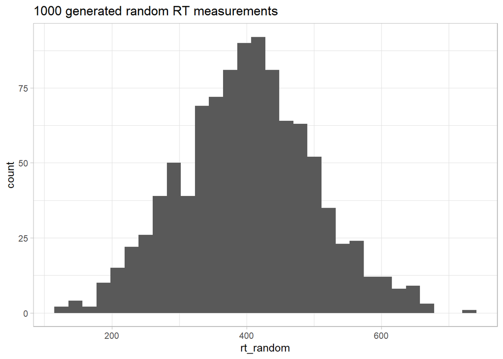

```r
set.seed(123)

rt_random <-
  rnorm(n = 1000, # How many values we want?
        mean = 400,
        sd = 100)

ggplot() +
  aes(x = rt_random) +
  geom_histogram(bins = 30) +
  labs(title = "1000 generated random RT measurements")
```

```r
# Define the groups
groups <- c("Alcohol", "Placebo")

# Create a dataframe
rt_df <-
  tibble(id = gl(n = 1000, k = 1), # Generate the id (everyone has 1 measurement)
         rt = rt_random, # Use the random rt variable that we generated
         group = gl(n = 2, k = 1, length = 1000, labels = groups) # Assign each case to one of the two groups
         ) %>%
    # Add the effect size(25) from the rt values to the alcohol group
    mutate(rt = if_else(group == "Alcohol",
                        rt + 25,
                        rt)) %>%
    # Let's set the placebo group the reference group
    mutate(group = fct_relevel(group, "Placebo"))

# This is how our dataframe will look like
rt_df
```

```
## # A tibble: 1,000 x 3
##    id       rt group
##    <fct> <dbl> <fct>
##  1 1      369. Alcohol
##  2 2      377. Placebo
##  3 3      581. Alcohol
##  4 4      407. Placebo
##  5 5      438. Alcohol
##  6 6      572. Placebo
##  7 7      471. Alcohol
##  8 8      273. Placebo
##  9 9      356. Alcohol
## 10 10     355. Placebo
## # ... with 990 more rows
```

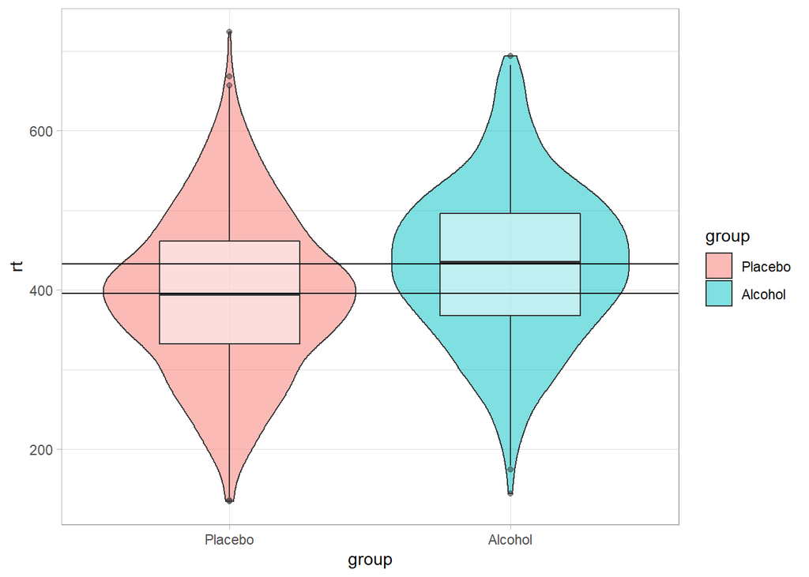

```r
# We can also visualize the difference between the groups
rt_df %>%
  group_by(group) %>%
  mutate(avg_rt = mean(rt)) %>%
  ggplot() +
  aes(x = group, y = rt) +
  geom_violin(aes(fill = group), alpha = .5) +
  geom_boxplot(alpha = .5, width = .5) +
  geom_hline(aes(yintercept = avg_rt))
```

## See if there is a significant difference

We will use a linear regression (in this case, equivalent to a t-test).

```r
lm(rt ~ group, data = rt_df) %>%
  summary()
```

```
##
## Call:
## lm(formula = rt ~ group, data = rt_df)
##
## Residuals:
##     Min      1Q  Median      3Q     Max
## -288.75  -65.18   -0.14   65.55  328.65
##
## Coefficients:
##              Estimate Std. Error t value Pr(>|t|)
## (Intercept)   395.455      4.429  89.295  < 2e-16 ***
## groupAlcohol   37.315      6.263   5.958 3.54e-09 ***
## ---
## Signif. codes:  0 '***' 0.001 '**' 0.01 '*' 0.05 '.' 0.1 ' ' 1
##
## Residual standard error: 99.03 on 998 degrees of freedom
## Multiple R-squared:  0.03435,    Adjusted R-squared:  0.03338
## F-statistic:  35.5 on 1 and 998 DF,  p-value: 3.537e-09
```

As we can see, there is a significant difference, and the difference is somewhat different to the 25 units that we wanted (due to the randomness of the data). However, we had 1000 participants, and we need to figure out if this effect is detectable with smaller sample size. To do that, we need to break down this previous prototype into substitutable elements.

It would be possible to run the previous the previous script several times, and see how the significance changes if we change the sample size or the standard deviation of the outcome measure. However, we could only say anything meaningful about each scenario, if we had several replications. Therefore, we should run the previous steps several times, and record the results. Sounds a tedious job! Fortunately, we can automate it!

# 2. Creating a generalized dataset creating function

In order to try out several different sample sizes, we need to create a function that generates the data with different parameters (such as the sample size), and evaluates if the result is significant or not.

Let’s make a function that generates a whole data frame! This way, we can generate as many replications as we want. To do this, we use the powerful feature of nested datasets. This means that each cell can hold a list element. For e.g. this way we can keep dataframes inside the cells of dataframes!

```r
# A function that generates a dataset based on theoretical parameters
# n: number of observations in a cell
# means: a vector of theoretical means for the groups
# sds: a vector of theoretical sds for the groups
# groups: a vector of group names

# These parameters are set here for testing purposes
n = 500
means = c(400, 425)
sds = 100
groups = c("Placebo", "Alcohol")

generate_dataset <- function(n, means, sds, groups){

# First we just define the groups
# Then we add the sample size and the theoretical parameters
tibble(group = groups,
       n = n,
       t_mean = means,
       t_sd = sds) %>%
  # Then we generate data into the cells as nested list values
  mutate(value = pmap(list(n, t_mean, t_sd),
                     ~rnorm(..1, ..2, ..3)),
         # Generate ids for each data point. This will make it possible to connect data
         # points like they were coming from the same person
         id = map2(group, n,
                   ~paste(.x, 1:.y, sep = "_"))) %>%
  # Remove the theoretical parameters, but keep the sample size
  select(-t_mean, -t_sd) %>%
  # Then unpack the data, that will be in long format
  unnest(c(value, id)) %>%
  # Make the first level of the groups the reference level
  mutate(group =  fct_relevel(group, groups[1]))

}
```

## Let’s verify that the function works as intended

- First we check if it can create a similar dataset than before
- Then we also check if it works with more than two groups

```r
rt_df <-
  generate_dataset(n = 500,
                   means = c(400, 425),
                   sds = 100,
                   groups = c("Placebo", "Alcohol"))

# Verify mean and sd
rt_df %>%
  group_by(group) %>%
  summarise(avg_rt = mean(value),
            sd_rt = sd(value),
            n = n())
```

```
## # A tibble: 2 x 4
##   group   avg_rt sd_rt     n
##   <fct>    <dbl> <dbl> <int>
## 1 Placebo   403.  99.3   500
## 2 Alcohol   431. 103.    500
```

```r
# More groups
generate_dataset(n = 500,
                 means = c(400, 425, 450),
                 sds = 100,
                 groups = c("Placebo", "Alcohol", "More alcohol")) %>%
  group_by(group) %>%
  summarise(avg_rt = mean(value),
            sd_rt = sd(value),
            n = n())
```

```
## # A tibble: 3 x 4
##   group        avg_rt sd_rt     n
##   <fct>         <dbl> <dbl> <int>
## 1 Placebo        394.  93.8   500
## 2 Alcohol        427. 102.    500
## 3 More alcohol   448.  98.8   500
```

# 3.Calculating statistical power

## Generating replications

First, we generate multiple replications for each dataset, so we can simulate the randomness of the statistical processes.

```r
sim_data <-
  tibble(dataset = 1:50) %>%
# Now, we simply iterate through each line, and create several datasets
  mutate(data = map(dataset,
                    ~generate_dataset(n = 100,
                                      means = c(400, 425),
                                      sds = 100,
                                      groups = c("Placebo",
                                                 "Alcohol"))
                    )
         )

sim_data
```

```
## # A tibble: 50 x 2
##    dataset data
##      <int> <list>
##  1       1 <tibble [200 x 4]>
##  2       2 <tibble [200 x 4]>
##  3       3 <tibble [200 x 4]>
##  4       4 <tibble [200 x 4]>
##  5       5 <tibble [200 x 4]>
##  6       6 <tibble [200 x 4]>
##  7       7 <tibble [200 x 4]>
##  8       8 <tibble [200 x 4]>
##  9       9 <tibble [200 x 4]>
## 10      10 <tibble [200 x 4]>
## # ... with 40 more rows
```

```r
# Let's check what's in each individual dataset
unnest(sim_data, data)
```

```
## # A tibble: 10,000 x 5
##    dataset group       n value id
##      <int> <fct>   <dbl> <dbl> <chr>
##  1       1 Placebo   100  548. Placebo_1
##  2       1 Placebo   100  259. Placebo_2
##  3       1 Placebo   100  212. Placebo_3
##  4       1 Placebo   100  372. Placebo_4
##  5       1 Placebo   100  443. Placebo_5
##  6       1 Placebo   100  387. Placebo_6
##  7       1 Placebo   100  513. Placebo_7
##  8       1 Placebo   100  375. Placebo_8
##  9       1 Placebo   100  283. Placebo_9
## 10       1 Placebo   100  552. Placebo_10
## # ... with 9,990 more rows
```

Now, we need to test our hypothesis on each generated dataset. Again, we can use the nested structure, so we will store the model for each dataset in a variable of the data frame.

```r
sim_result <-
  sim_data %>%
  mutate(model = map(data,
                     # Run the formula to test the hypothesis
                     ~lm(value ~ group, data = .x) %>%
                     # Put the results into a tidy data frame
                      tidy()
                     ))

# What's in the model variable? A tibble of statistical output
sim_result %>%
  unnest(model)
```

```
## # A tibble: 100 x 7
##    dataset data               term        estimate std.error statistic   p.value
##      <int> <list>             <chr>          <dbl>     <dbl>     <dbl>     <dbl>
##  1       1 <tibble [200 x 4]> (Intercept)   407.       10.3     39.6   4.85e- 96
##  2       1 <tibble [200 x 4]> groupAlcoh~    16.4      14.5      1.13  2.59e-  1
##  3       2 <tibble [200 x 4]> (Intercept)   375.        8.96    41.8   2.89e-100
##  4       2 <tibble [200 x 4]> groupAlcoh~    57.2      12.7      4.52  1.08e-  5
##  5       3 <tibble [200 x 4]> (Intercept)   415.       11.0     37.7   2.15e- 92
##  6       3 <tibble [200 x 4]> groupAlcoh~     1.84     15.5      0.119 9.06e-  1
##  7       4 <tibble [200 x 4]> (Intercept)   396.        9.08    43.6   1.91e-103
##  8       4 <tibble [200 x 4]> groupAlcoh~    28.0      12.8      2.18  3.04e-  2
##  9       5 <tibble [200 x 4]> (Intercept)   396.       10.4     37.9   9.87e- 93
## 10       5 <tibble [200 x 4]> groupAlcoh~    23.6      14.8      1.60  1.12e-  1
## # ... with 90 more rows
```

```r
# We can select the relevant row and check if the p value is below the significance level.
sim_result %>%
# Get the relevant p values out
      mutate(p = map_dbl(model,
                         ~filter(.x, str_detect(term, "^group")) %>%
                          pull(p.value)),
# Generate a variable that evaluates if the significance is under the threshold
             sig = p <= .05) %>%
# We can now calculate the proportion when the H0 was rejected
      summarise(power = mean(sig))
```

```
## # A tibble: 1 x 1
##   power
##   <dbl>
## 1   0.5
```

# 4. Calculate power for different sample sizes

To be able to create replications for each scenario that we test, we need to define the sample sizes, and also the number of replications for each sample size. The more datasets we have for each sample size, the more reliable our estimation gets. Each dataset should be numbered, just as each participant in the datasets. We can use `crossing()` function to do this. Crossing creates rows for every combinations of the specified variables in a dataset.

Let’s define the minimum sample size as 30, and increase it until 300 with increments of 30. We can do this using the `seq()` function.

```r
multiple_n <-
  crossing(group_size = seq(from = 30, to = 300, by = 30),
           replication = 1:50) %>%
  mutate(dataset = map(group_size,
                       ~generate_dataset(n = .x,
                                         means = c(400, 425),
                                         sds = 100,
                                         groups = c("Placebo",
                                                    "Alcohol"))
                       )
         )

multiple_n
```

```
## # A tibble: 500 x 3
##    group_size replication dataset
##         <dbl>       <int> <list>
##  1         30           1 <tibble [60 x 4]>
##  2         30           2 <tibble [60 x 4]>
##  3         30           3 <tibble [60 x 4]>
##  4         30           4 <tibble [60 x 4]>
##  5         30           5 <tibble [60 x 4]>
##  6         30           6 <tibble [60 x 4]>
##  7         30           7 <tibble [60 x 4]>
##  8         30           8 <tibble [60 x 4]>
##  9         30           9 <tibble [60 x 4]>
## 10         30          10 <tibble [60 x 4]>
## # ... with 490 more rows
```

## Sidenote: Avoiding the hardcoding of values into function calls

It is not a good practice to hard-code the parameters into functions. The good practice is to define the parameters in the beginning of the script, than we can feed the variables to the function. This way you only need to change your script at one place. Let’s do that. Also, please notice that the simulation now is starting to require more computational power. If you set a high number of replications, and wide range of sample sizes, it may get quite slow. For now, let’s keep the number of replications low, so we don’t need to wait for too long to run our code. We will have some tricks to speed up the code later!

```r
# Let's keep the parameters separate from the functions!

# These parameters define the parameter matrix

replications = 50 # The number of replications for each scenario
min_sample = 30
max_sample = 300
sample_increment = 30

# These parameters define the datasets
means = c(400, 425) # The mean for the groups
sds = 100
groups = c("Placebo", "Alcohol")

# These parameters define the evaluation of the results
significance_level = .05 # The threshold for false positives (we will need this later)

# This is how the function call should look like:
multiple_n <-
  crossing(group_size = seq(from = min_sample,
                            to = max_sample,
                            by = sample_increment),
           replication = 1:replications) %>%
  # Now, we simply iterate through each line, and create a dataset
  mutate(data = map(group_size,
                    ~generate_dataset(n = .x,
                                      means = means,
                                      sds = sds,
                                      groups = groups)))

multiple_n
```

```
## # A tibble: 500 x 3
##    group_size replication data
##         <dbl>       <int> <list>
##  1         30           1 <tibble [60 x 4]>
##  2         30           2 <tibble [60 x 4]>
##  3         30           3 <tibble [60 x 4]>
##  4         30           4 <tibble [60 x 4]>
##  5         30           5 <tibble [60 x 4]>
##  6         30           6 <tibble [60 x 4]>
##  7         30           7 <tibble [60 x 4]>
##  8         30           8 <tibble [60 x 4]>
##  9         30           9 <tibble [60 x 4]>
## 10         30          10 <tibble [60 x 4]>
## # ... with 490 more rows
```

## Calculate the required sample size

Now, we can calculate the statistical power for each sample size. Thus, we can learn how many participants are needed to achieve a certain statistical power.

```r
multiple_result <-
  multiple_n %>%
  mutate(model = map(data,
                     # Run the formula to test the hypothesis
                     ~lm(value ~ group, data = .x) %>%
                     # Put the results into a tidy dataframe
                      tidy()
                     ))

multiple_result
```

```
## # A tibble: 500 x 4
##    group_size replication data              model
##         <dbl>       <int> <list>            <list>
##  1         30           1 <tibble [60 x 4]> <tibble [2 x 5]>
##  2         30           2 <tibble [60 x 4]> <tibble [2 x 5]>
##  3         30           3 <tibble [60 x 4]> <tibble [2 x 5]>
##  4         30           4 <tibble [60 x 4]> <tibble [2 x 5]>
##  5         30           5 <tibble [60 x 4]> <tibble [2 x 5]>
##  6         30           6 <tibble [60 x 4]> <tibble [2 x 5]>
##  7         30           7 <tibble [60 x 4]> <tibble [2 x 5]>
##  8         30           8 <tibble [60 x 4]> <tibble [2 x 5]>
##  9         30           9 <tibble [60 x 4]> <tibble [2 x 5]>
## 10         30          10 <tibble [60 x 4]> <tibble [2 x 5]>
## # ... with 490 more rows
```

```r
# We can  select the term of interest that evaluates the hypothesis, and see if it is significant or not

multiple_power <-
  multiple_result %>%
    # Extract the p value of the interaction from the model
    mutate(p = map_dbl(model,
                       ~filter(.x, str_detect(term, "^group")) %>%
                        pull(p.value)),
# Generate a variable that evaluates if the significance is under the threshold
           sig = p <= significance_level) %>%
# See the proportion when we rejected the null hypothesis for each sample size. This is actually the statistical power!!
  group_by(group_size) %>%
  summarise(power = mean(sig))

multiple_power
```

```
## # A tibble: 10 x 2
##    group_size power
##         <dbl> <dbl>
##  1         30  0.22
##  2         60  0.38
##  3         90  0.32
##  4        120  0.56
##  5        150  0.62
##  6        180  0.58
##  7        210  0.76
##  8        240  0.78
##  9        270  0.82
## 10        300  0.92
```

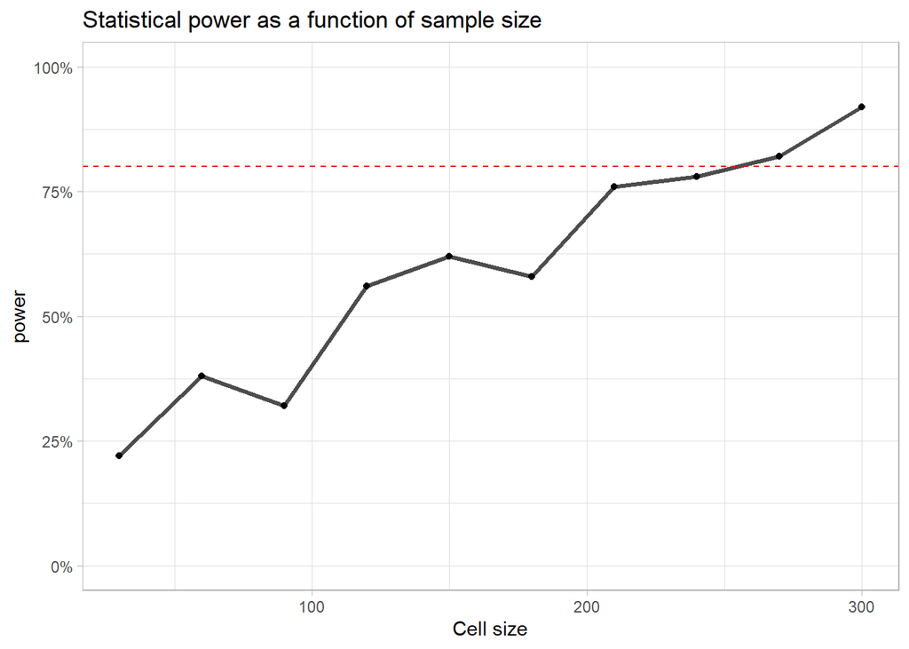

```r
# Visualize results
multiple_power %>%
  ggplot() +
  aes(x = group_size, y = power) +
  geom_point() +
  geom_line(alpha = .7, size = 1.2) +
  scale_y_continuous(limits = c(0, 1), labels = scales::percent_format()) +
  geom_hline(yintercept = .8, lty = "dashed", color = "red") +
  labs(x = "Cell size",
       title = "Statistical power as a function of sample size")
```

# 5. Improving performance

You may see that every time we regenerate the data, the line looks a bit differently. This is because of the randomness. We can reduce this randomness by increasing the number of replications. 10,000 replication for each sample size will make the line fairly robust. However, it can also make our simulation become super slow! There are a few ways to overcome this problem.

## Interpolate between sample sizes

When we created our parameter matrix, we could have chosen to increase the sample size one-by-one, instead of using increments of 30. This would be very slow. But if we want to calculate the *exact* sample size to achieve 80% power, we can interpolate between the values (just as the line interpolated on the figure).

```r
interpolated_power <-
  # Create all possible sample sizes between the two extremes
  tibble(group_size = min_sample:max_sample) %>%
  # Add existing data
  left_join(multiple_power, by = "group_size") %>%
  # Use linear interpolation
  mutate(power = approx(x = group_size,
                        y = power,
                        xout = group_size)$y)


head(interpolated_power, 20)
```

```
## # A tibble: 20 x 2
##    group_size power
##         <dbl> <dbl>
##  1         30 0.22
##  2         31 0.225
##  3         32 0.231
##  4         33 0.236
##  5         34 0.241
##  6         35 0.247
##  7         36 0.252
##  8         37 0.257
##  9         38 0.263
## 10         39 0.268
## 11         40 0.273
## 12         41 0.279
## 13         42 0.284
## 14         43 0.289
## 15         44 0.295
## 16         45 0.3
## 17         46 0.305
## 18         47 0.311
## 19         48 0.316
## 20         49 0.321
```

```r
# Calculate the exact number of participants needed in each cell for specific power
interpolated_power %>%
  transmute(group_size,
            `>= .80` = power >= .80,
            `>= .90` = power >= .90) %>%
  pivot_longer(-group_size,
               names_to = "power") %>%
  # Keep only the value where the power first surpasses the threshold
  filter(value) %>%
  group_by(power) %>%
  summarise(required_cell_size = first(group_size))
```

```
## # A tibble: 2 x 2
##   power  required_cell_size
##   <chr>               <dbl>
## 1 >= .80                255
## 2 >= .90                294
```

## Using extra computational power to increase speed

For larger and more complex datasets, more replications, and calculations that require a lot of processing power, the power analysis can become slow. To increase speed, you can: - Use multiple processors (parallel processing) - Use the GPU - Use remote servers (e.g. Google cloud, university cluster, etc.)

Here, I only add the multiple processing, using the `{furrr}` package. This packages can parallelize all `map()` operations seamlessly. For that, you have to load the package, set up the parallel processing, and use the furrr variant of the function (e.g. `future_map()`).

To set up parallel processing, just put this in the beginning of your script. Note that this may not work in non-Windows operating systems.

```r
# This chunk is not evaluated, only code is shown
library(furrr)
plan(multisession(workers = availableCores()))


set.seed(123)

# Let's increase the number of replications
# NOTE: Increase this number for more accurate results
replications = 500

multiple_n <-
  crossing(group_size = seq(from = min_sample,
                            to = max_sample,
                            by = sample_increment),
           replication = 1:replications) %>%
  # Mind that now I use future_map() in the next line
  mutate(data = future_map(group_size,
                          ~generate_dataset(n = .x,
                                            means = means,
                                            sds = sds,
                                            groups = groups),
                          # Use parallel-safe random numbers
                          .options = furrr_options(seed = TRUE),
                          # Add progress bar
                          .progress = TRUE
                          )
         )

multiple_power <-
  multiple_n %>%
  # future_map() in next line, you can use a progress bar
  mutate(model = future_map(data,
                           ~lm(value ~ group, data = .x) %>%
                            # Make sure we use the tidy function from broom
                            broom::tidy(),
                            .progress = TRUE)) %>%
  # It is not worth using future_map for fast tasks
  mutate(p = map_dbl(model,
                     ~filter(.x, str_detect(term, "^group")) %>%
                     pull(p.value)),
         sig = p <= significance_level) %>%
  group_by(group_size) %>%
  summarise(power = mean(sig))

multiple_power

# Visualize results
multiple_power %>%
  ggplot() +
  aes(x = group_size, y = power) +
  geom_point() +
  geom_line(alpha = .7, size = 1.2) +
  scale_y_continuous(limits = c(0, 1), labels = scales::percent_format()) +
  geom_hline(yintercept = .8, lty = "dashed", color = "red") +
  labs(x = "Cell size",
       title = "Statistical power as a function of sample size")
```

# 6. Complex designs

At this point, we may want to abandon our own dataset generating function, because we learned how it works, and how to write one. Instead, I recommend using the `sim_design()` function from the `{faux}` package, that can generate datasets for complex designs. See vignette here: https://debruine.github.io/faux/articles/sim_design.html. See exercises.

The only problem with `sim_design()` is that it can only simulate normally distributed variables. However, it has functions to convert between normal and other distributions (e.g. binomial, Likert). See: https://debruine.github.io/faux/articles/distributions.html so generally we can first generate the datasets with normal variables, and transform the variables into differently distributed variables.

Let’s try a more complex study design!

Study 2: We investigate the same problem, but this time, we employ a pre-post design, while still having the groups. We will use `sim_design()`

```r
study2 <-
  sim_design(n = 100,
             between = list(group = c("Placebo", "Alcohol")),
             within = list(measurement = c("Pre", "Post")),
             mu = list(Placebo = c(400, 395),
                       Alcohol = c(400, 420)),
             sd = 10,
             dv = "rt",
             # We should specify the correlation between the measurements
             r = .5,
             plot = FALSE)

head(study2, 10)
```

```
##      id   group      Pre     Post
## 1  S001 Placebo 392.3033 378.1166
## 2  S002 Placebo 403.4907 396.8986
## 3  S003 Placebo 380.0383 381.1715
## 4  S004 Placebo 394.3222 412.1151
## 5  S005 Placebo 396.6659 396.6644
## 6  S006 Placebo 400.8365 413.2266
## 7  S007 Placebo 382.1406 392.6037
## 8  S008 Placebo 412.4086 396.7924
## 9  S009 Placebo 386.9191 395.9102
## 10 S010 Placebo 388.1039 391.4093
```

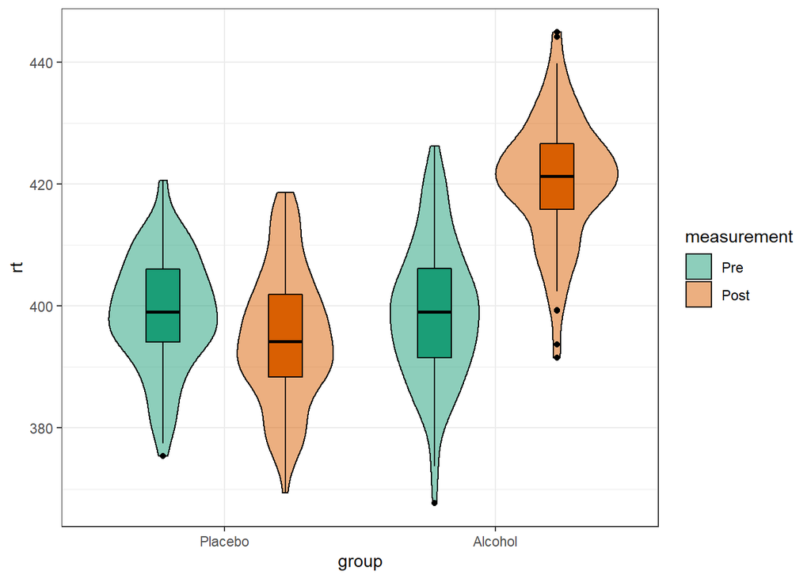

```r
plot_design(study2)
```

```r
# Put to long format
study_long <-
  wide2long(study2) %>%
  mutate(measurement = fct_relevel(measurement, "Pre"))

# Test the hypothesis

lmer(rt ~ group * measurement + (1|id), data = study_long) %>%
  summary()
```

```
## Linear mixed model fit by REML. t-tests use Satterthwaite's method [
## lmerModLmerTest]
## Formula: rt ~ group * measurement + (1 | id)
##    Data: study_long
##
## REML criterion at convergence: 2942.5
##
## Scaled residuals:
##      Min       1Q   Median       3Q      Max
## -2.82558 -0.52815 -0.03279  0.56100  2.18383
##
## Random effects:
##  Groups   Name        Variance Std.Dev.
##  id       (Intercept) 55.61    7.457
##  Residual             53.84    7.338
## Number of obs: 400, groups:  id, 200
##
## Fixed effects:
##                              Estimate Std. Error       df t value Pr(>|t|)
## (Intercept)                  398.9758     1.0462 314.7468 381.363  < 2e-16 ***
## groupAlcohol                   0.1119     1.4795 314.7468   0.076 0.939759
## measurementPost               -4.0129     1.0377 198.0000  -3.867 0.000149 ***
## groupAlcohol:measurementPost  25.6023     1.4675 198.0000  17.446  < 2e-16 ***
## ---
## Signif. codes:  0 '***' 0.001 '**' 0.01 '*' 0.05 '.' 0.1 ' ' 1
##
## Correlation of Fixed Effects:
##             (Intr) grpAlc msrmnP
## groupAlcohl -0.707
## measrmntPst -0.496  0.351
## grpAlchl:mP  0.351 -0.496 -0.707
```

## Adding confounders

What if we want to add age into our model as a predictor? We can add variables that are correlated with other pre-existing variables. Age is a bit tricky, because it must be an integer, and it should be within reasonable boundaries. So after creating it, it must be adjusted.

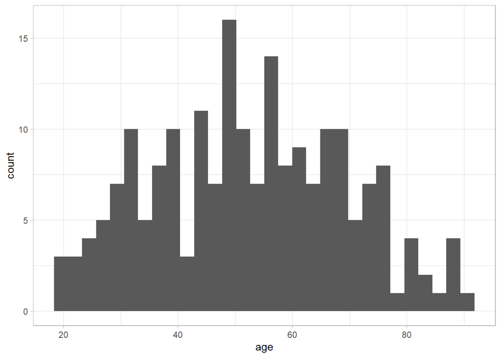

```r
# rnorm_pre generates a randomly distributed variable that is correlated with a pre-existing variable

study2 <-
  study2 %>%
  mutate(age = rnorm_pre(x = Pre, mu = 50, sd = 20, r = .2) %>%
               # This function truncates the variable values
               norm2trunc(min = 18, max = 90) %>%
               round(0))

# Visualize age
ggplot(study2) +
  aes(x = age) +
  geom_histogram()
```

```r
# Test the hypothesis

lmer(rt ~ group * measurement + age + (1|id),
     data = wide2long(study2,
                      dv = "rt",
                      within_factors = c("Placebo", "Alcohol"),
                      within_cols = 3:4)) %>%
  summary()
```

```
## Linear mixed model fit by REML. t-tests use Satterthwaite's method [
## lmerModLmerTest]
## Formula: rt ~ group * measurement + age + (1 | id)
##    Data:
## wide2long(study2, dv = "rt", within_factors = c("Placebo", "Alcohol"),
##     within_cols = 3:4)
##
## REML criterion at convergence: 2941.6
##
## Scaled residuals:
##      Min       1Q   Median       3Q      Max
## -2.75401 -0.52503 -0.00756  0.56757  2.21548
##
## Random effects:
##  Groups   Name        Variance Std.Dev.
##  id       (Intercept) 53.71    7.329
##  Residual             53.84    7.338
## Number of obs: 400, groups:  id, 200
##
## Fixed effects:
##                               Estimate Std. Error        df t value Pr(>|t|)
## (Intercept)                  394.14060    2.28119 218.43325 172.778  < 2e-16
## groupAlcohol                   0.30054    1.46878 315.14114   0.205 0.838001
## measurementPost               -4.01288    1.03769 198.00000  -3.867 0.000149
## age                            0.09026    0.03793 197.00000   2.380 0.018281
## groupAlcohol:measurementPost  25.60233    1.46751 198.00000  17.446  < 2e-16
##
## (Intercept)                  ***
## groupAlcohol
## measurementPost              ***
## age                          *
## groupAlcohol:measurementPost ***
## ---
## Signif. codes:  0 '***' 0.001 '**' 0.01 '*' 0.05 '.' 0.1 ' ' 1
##
## Correlation of Fixed Effects:
##             (Intr) grpAlc msrmnP age
## groupAlcohl -0.369
## measrmntPst -0.227  0.353
## age         -0.891  0.054  0.000
## grpAlchl:mP  0.161 -0.500 -0.707  0.000
```

# FINAL EXERCISE

Let’s make a power analysis for this design! Our hypothesis: Alcohol will increase the reaction time after drinking it, vs. drinking placebo, even after controlling for the confounding effect of age. You can use the parameters that we used in the chunk above. What is the exact required sample size?

```r
# Create dataset creating function
set.seed(2022)

n = 100
between = list(group = c("Placebo", "Alcohol"))
within = list(measurement = c("Pre", "Post"))
mus = list(Placebo = c(400, 405),
           Alcohol = c(400, 410))
sds = 10
r = .5
replications = 100

generate_complex <- function(n, between, within, mu, sd, r){
  # Create the dataset
  sim_design(n = n,
             between = between,
             within = within,
             mu = mus,
             sd = sds,
             dv = "rt",
             r = r,
             plot = FALSE) %>%
  # Create and the age confounder
  mutate(age = rnorm_pre(x = Pre, mu = 50, sd = 20, r = .2) %>%
               norm2trunc(min = 18, max = 90) %>%
               round(0)) %>%
  wide2long() %>%
  # Set baselines
  mutate(measurement = fct_relevel(measurement, "Pre"),
         group = fct_relevel(group, "Placebo"))
}

# Create parameter matrix
# Generate multiple datasets for each sample size

study2_data <-
  crossing(cell_size = seq(10, 100, 10),
           sample = 1:replications) %>%
  mutate(data = map(cell_size,
                    ~generate_complex(.x, between, within, mus, sds, r)))

# Evaluate the models
study2_result <-
  study2_data %>%
  mutate(
    # Calculate the test statistics
         model = map(data,
                     ~lmer(rt ~ group * measurement + age + (1|id), data = .x) %>%
                       tidy()),
    # Get the p values for the interaction
         p = map_dbl(model,
                     ~filter(.x, term == "groupAlcohol:measurementPost") %>%
                      pull(p.value)),
    # Determine if the test is significant
         sig = p <.05) %>%
    # Calculate the average power by cell size
  group_by(cell_size) %>%
  summarise(power = mean(sig))

# Interpolate between values to find exact required sample size
study2_power <-
  tibble(cell_size = 10:100) %>%
  left_join(study2_result, by = "cell_size") %>%
  mutate(power = approx(x = cell_size,
                        y = power,
                        xout = cell_size)$y)

study2_power %>%
  filter(power >= .8)
```

```
## # A tibble: 33 x 2
##    cell_size power
##        <dbl> <dbl>
##  1        68 0.812
##  2        69 0.826
##  3        70 0.84
##  4        71 0.845
##  5        72 0.85
##  6        73 0.855
##  7        74 0.86
##  8        75 0.865
##  9        76 0.87
## 10        77 0.875
## # ... with 23 more rows
```

```r
required_n <-
  study2_power %>%
  filter(power >= .8) %>%
  summarise(first(cell_size)) %>%
  pull()

required_n
```

```
## [1] 68
```

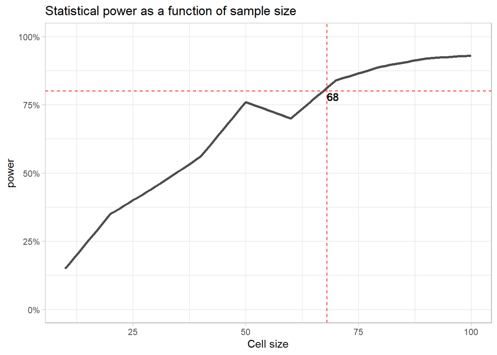

```r
# Visualize results
study2_power %>%
  ggplot() +
  aes(x = cell_size, y = power) +
  geom_line(alpha = .7, size = 1.2) +
  scale_y_continuous(limits = c(0, 1), labels = scales::percent_format()) +
  geom_hline(yintercept = .8, lty = "dashed", color = "red") +
  geom_vline(xintercept = required_n, lty = "dashed", color = "red") +
  geom_text(aes(label = required_n), x = required_n, y = .78, hjust = 0) +
  labs(x = "Cell size",
       title = "Statistical power as a function of sample size")
```

```r
# NOTE: We can make the line more accurate if we use more replications, e.g. 10k
```

**Answer**: Statistical power is reached when we have 68 participants / cell (condition) which is 136 participants altogether. Please mind that this estimation can be made more accurate with increasing the number of replications (e.g. to 10,000).